## Цель и задачи этого маленького проектика

Вышло вполне интересно и занимательно анализировать пики чипсека для 4 клеточных линий, пришло время расширяться!

Попробуем проанализировать пики для ENCODE cell lines!

Итак, поехали!

## Импорт и контроль качества данных

Импортируем функцию по обработке файлов из предыдущего проекта

```r
source("~/R_stuff/Functions.R")
setwd("~/R_stuff/ENCODE_NF-kB_peaks/")
```

Теперь считаем файлы с пиками с помощью этой чудодейственной функции

```r
setwd("~/R_stuff/ENCODE_NF-kB_peaks/Raw_files/")
GM10847_peaks <- read.narrowpeak("GM10847_p65vsInput_TNFa_peaks.narrowPeak")
GM12878_peaks <- read.narrowpeak("GM12878_p65vsInput_TNFa_peaks.narrowPeak")
GM12891_peaks <- read.narrowpeak("GM12891_p65vsInput_TNFa_peaks.narrowPeak")
GM12892_peaks <- read.narrowpeak("GM12892_p65vsInput_TNFa_peaks.narrowPeak")
GM15510_peaks <- read.narrowpeak("GM15510_p65vsInput_TNFa_peaks.narrowPeak")
GM18505_peaks <- read.narrowpeak("GM18505_p65vsInput_TNFa_peaks.narrowPeak")
GM18526_peaks <- read.narrowpeak("GM18526_p65vsInput_TNFa_peaks.narrowPeak")
GM18951_peaks <- read.narrowpeak("GM18951_p65vsInput_TNFa_peaks.narrowPeak")
GM19099_peaks <- read.narrowpeak("GM19099_p65vsInput_TNFa_peaks.narrowPeak")
Beas_peaks <- read.narrowpeak("Beas_TNFvsInput_peaks.narrowPeak")
AC16_peaks <- read.narrowpeak("AC16_TNFvsAsis_peaks.narrowPeak")
```

Итак, количество пиков по линиям

*GM10847 - 2255* GM12878 - 21134 *GM12891 - 12113* GM12892 - 3134 *GM15510 - 1935* GM18505 - 2005 *GM18526 - 713* GM18951 - 4274 *GM19099 - 8096* BEAS - 9232 *AC16 - 1983

Выглядит несколько подозрительно, очень большой разброс!

Поглядим на графики

Клеточная линия

Количество пиков

Распределение ридов

GM10847

2255

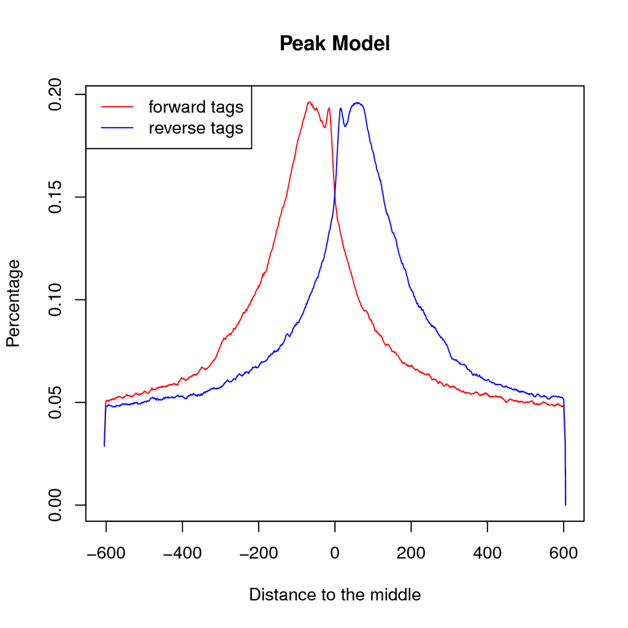

GM12878

21134

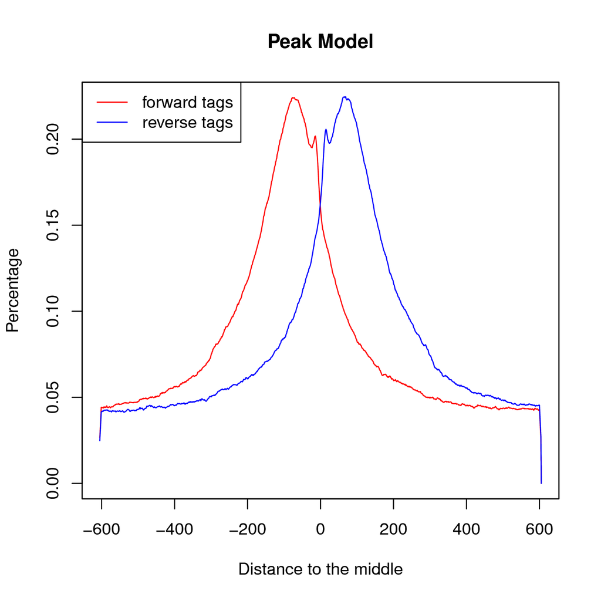

GM12891

12113

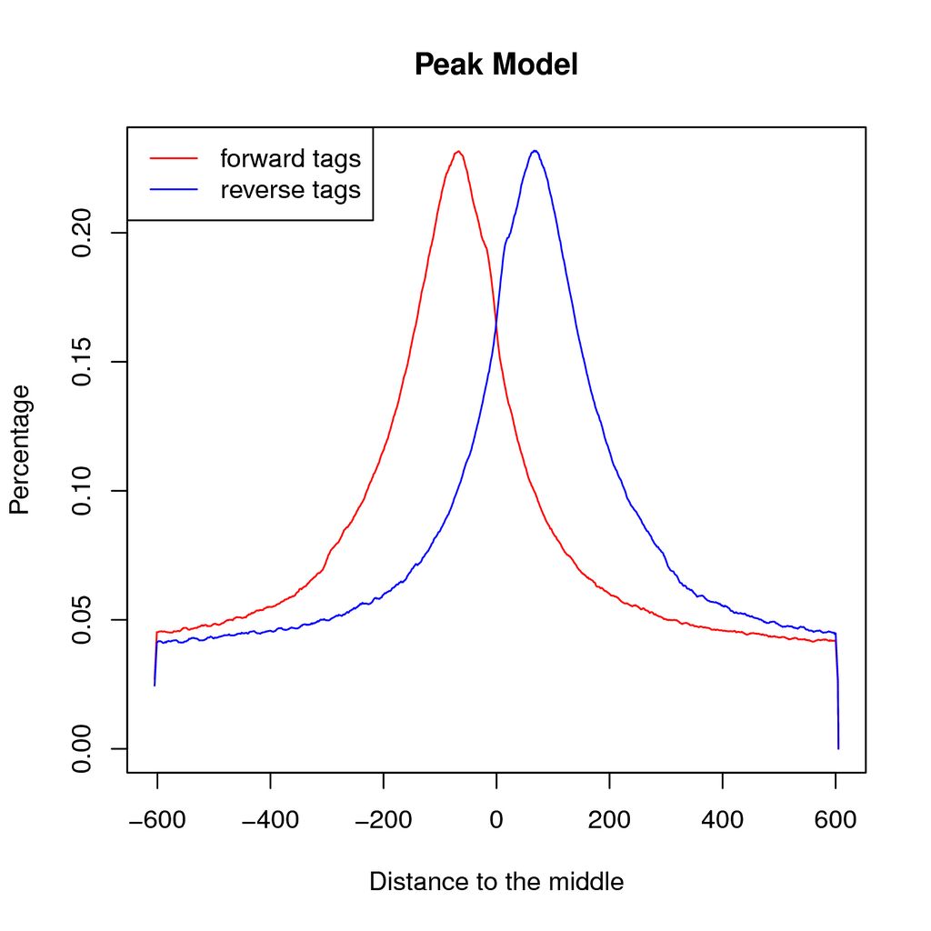

GM12892

3134

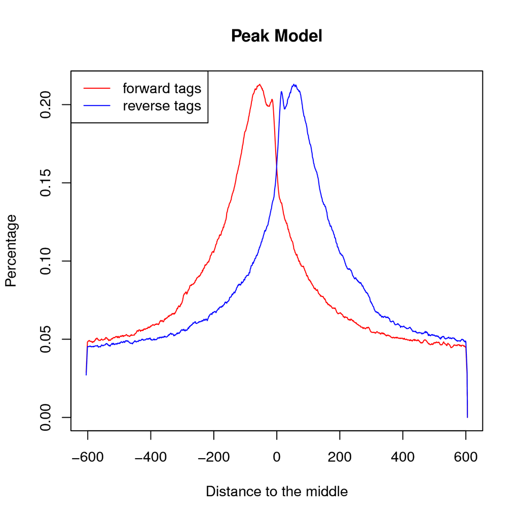

GM15510

1935

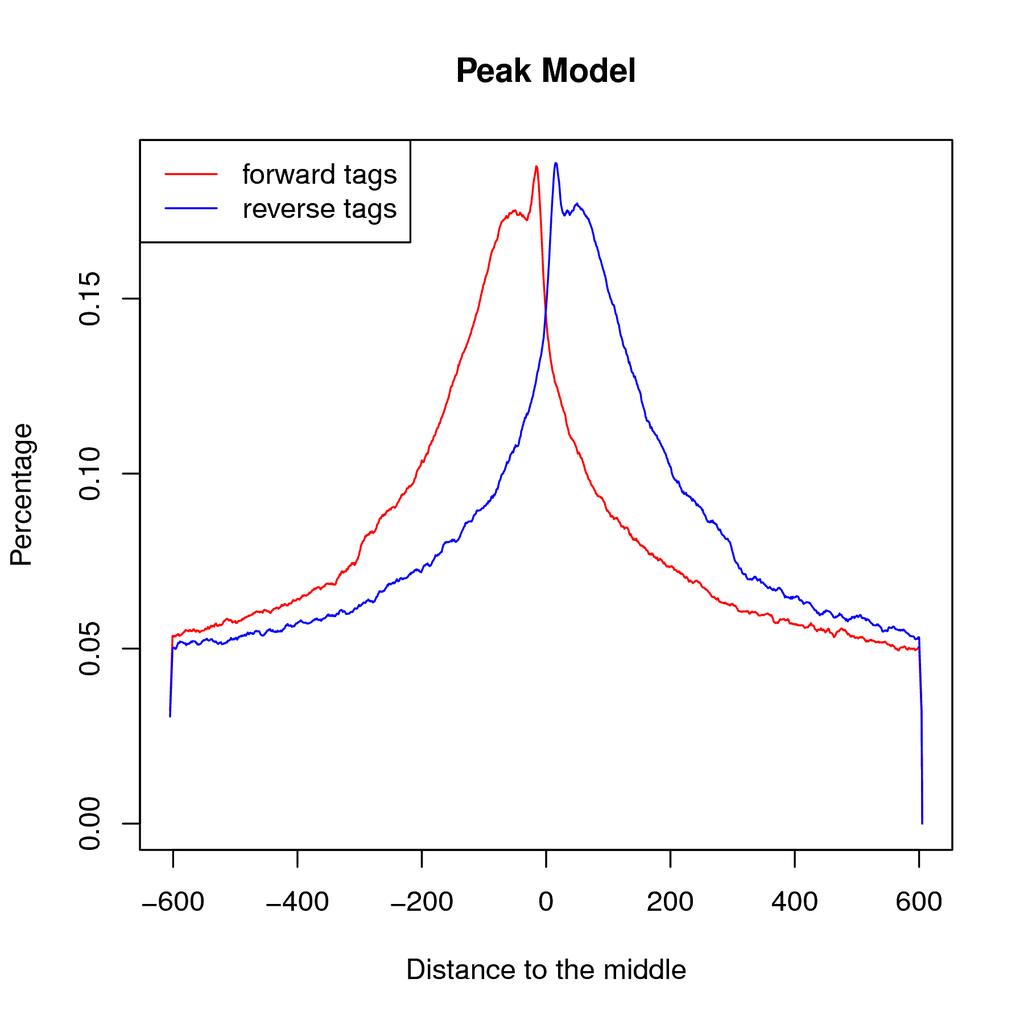

GM18505

2005

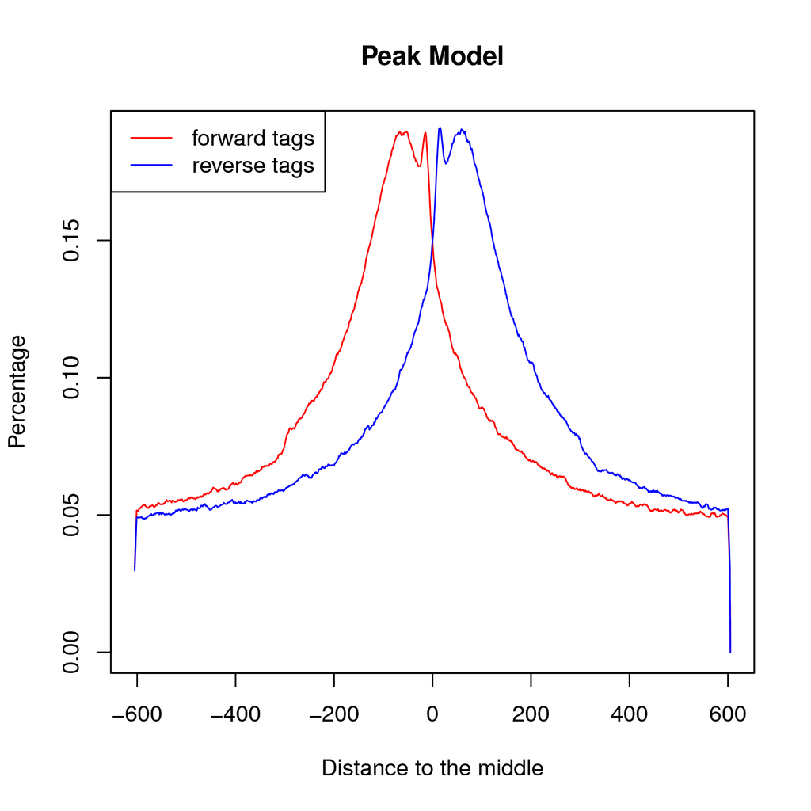

GM18951

4274

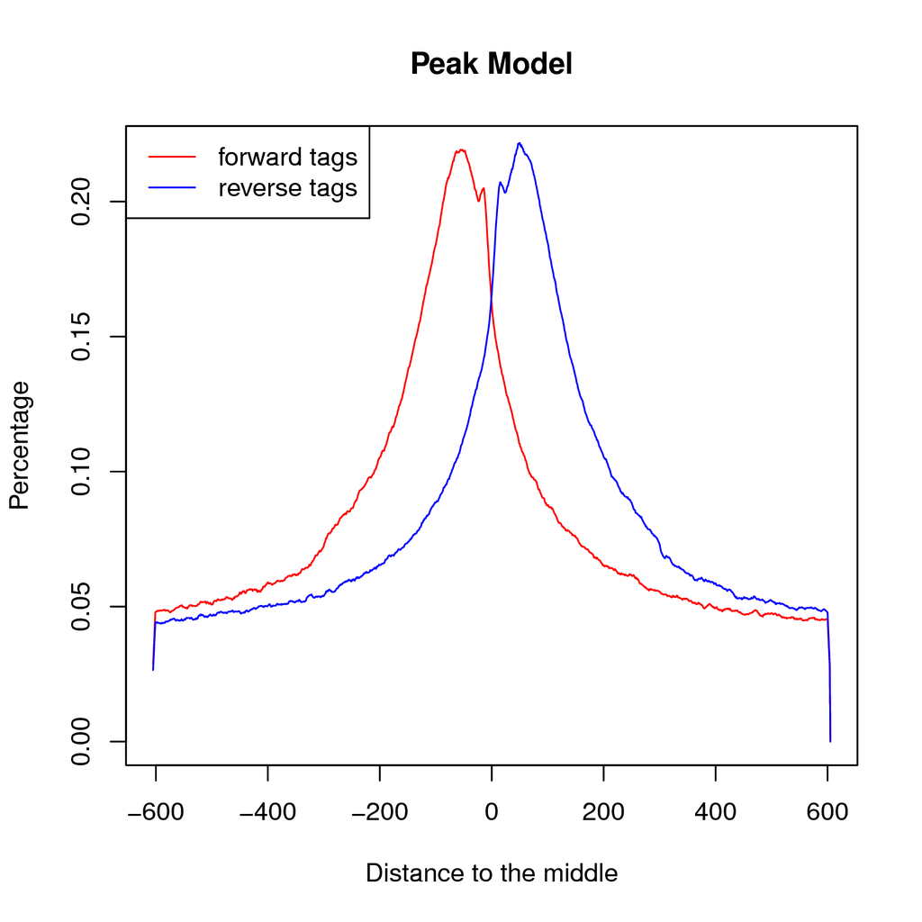

GM19099

8096

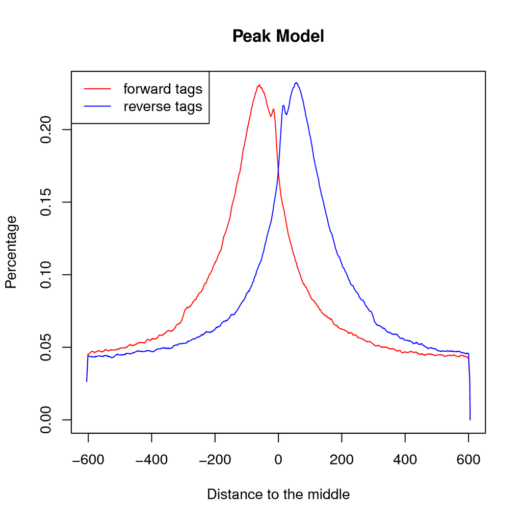

BEAS

9232

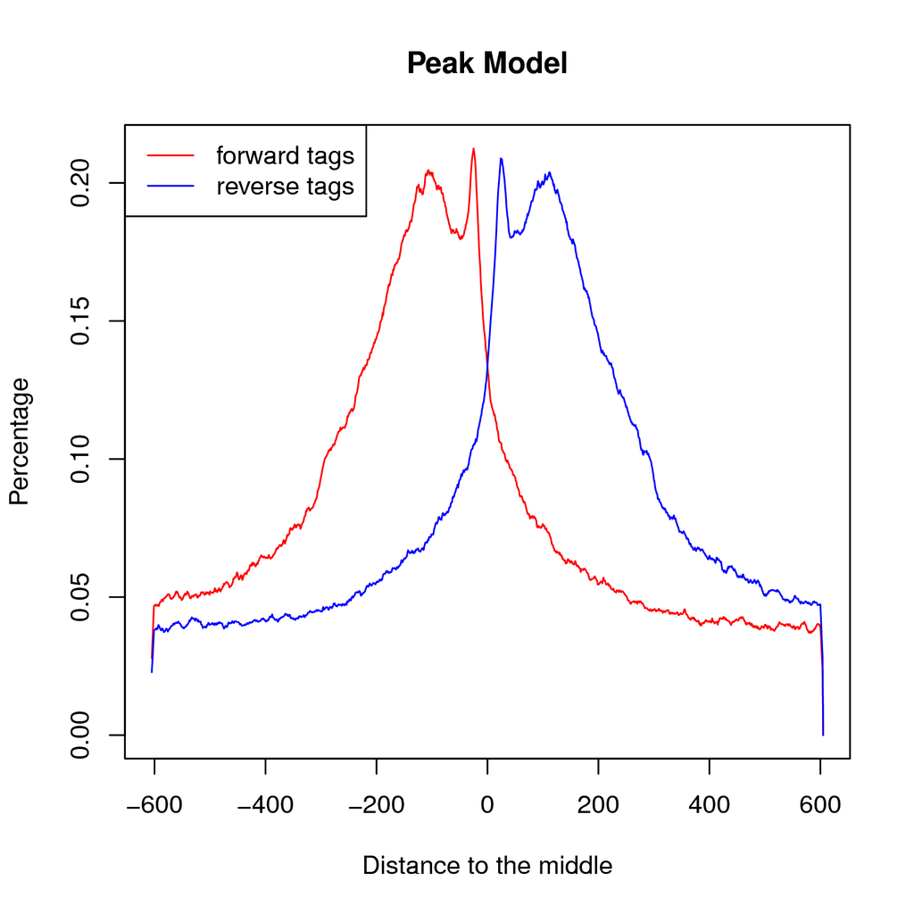

AC16

1983

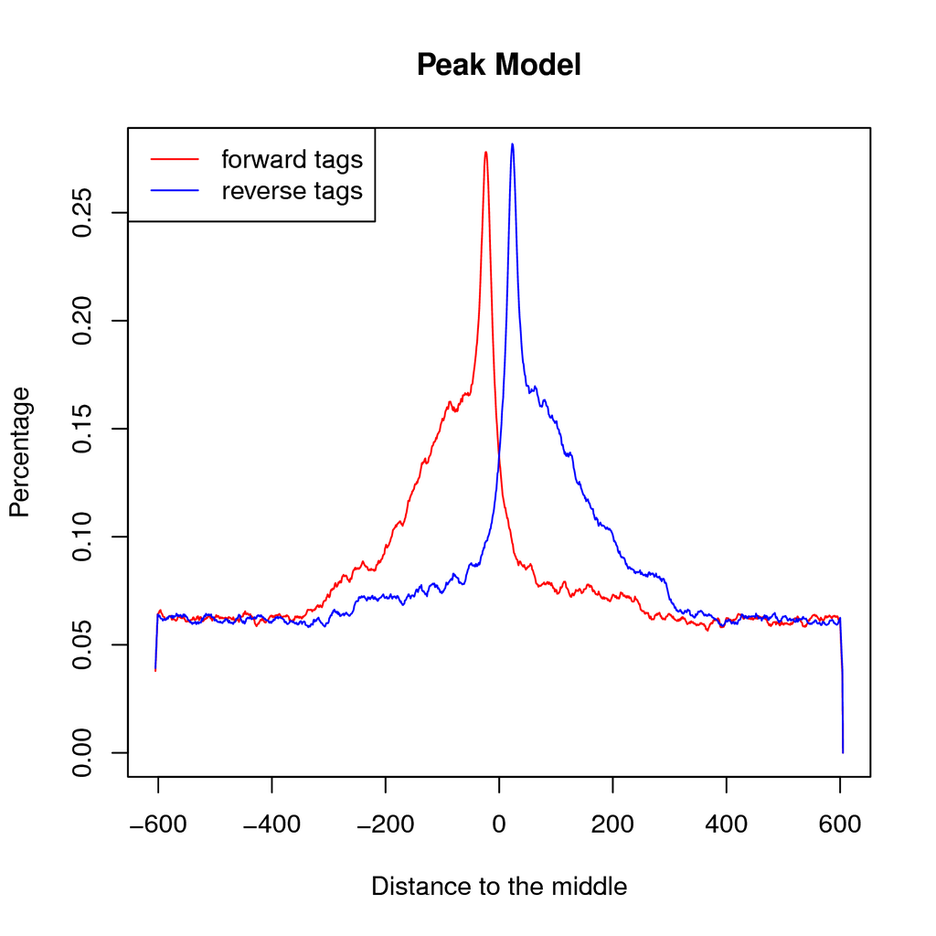

Ну в принципе, везде нормально c небольшими допущениями

А все остальные сложим в одну data.table И добавим туда наши линии из предыдущего проекта.

```r
setwd("~/R_stuff/ENCODE_NF-kB_peaks/Raw_files/")

A549_peaks <- read.narrowpeak("A549_TNF_vs_bg_peaks.narrowPeak")
HUVEC_peaks <- read.narrowpeak("HUVEC_TNFvsASIS_peaks.narrowPeak")
IMR90_peaks <- read.narrowpeak("IMR90_TNFvsASIS_peaks.narrowPeak")
SGBS_peaks <- read.narrowpeak("SGBS_TNFvsVeh_peaks.narrowPeak")

AC16_peaks$Cell_line <- "AC16"
A549_peaks$Cell_line <- "A549"
Beas_peaks$Cell_line <- "Beas"
HUVEC_peaks$Cell_line <- "HUVEC"
IMR90_peaks$Cell_line <- "IMR90"
SGBS_peaks$Cell_line <- "SGBS"

rm(GM18526_peaks)

GM10847_peaks$Cell_line <- "GM10847"
GM12878_peaks$Cell_line <- "GM12878"
GM12891_peaks$Cell_line <- "GM12891"
GM12892_peaks$Cell_line <- "GM12892"
GM15510_peaks$Cell_line <- "GM15510"
GM18505_peaks$Cell_line <- "GM18505"
GM18951_peaks$Cell_line <- "GM18951"
GM19099_peaks$Cell_line <- "GM19099"

all_peaks <- rbindlist(list(GM10847_peaks, GM12878_peaks, GM12891_peaks,
                            GM12892_peaks, GM15510_peaks, GM18505_peaks,
                            GM18951_peaks, GM19099_peaks, A549_peaks,
                            HUVEC_peaks, IMR90_peaks, SGBS_peaks,
                            Beas_peaks, AC16_peaks))

rm(GM10847_peaks, GM12878_peaks, GM12891_peaks,
                            GM12892_peaks, GM15510_peaks, GM18505_peaks,
                            GM18951_peaks, GM19099_peaks, A549_peaks,
                            HUVEC_peaks, IMR90_peaks, SGBS_peaks,
                            Beas_peaks, AC16_peaks)
```

Позабавимся гистограммками!

Гистограммка по fold_change дает странные результаты, но вполне объяснимые

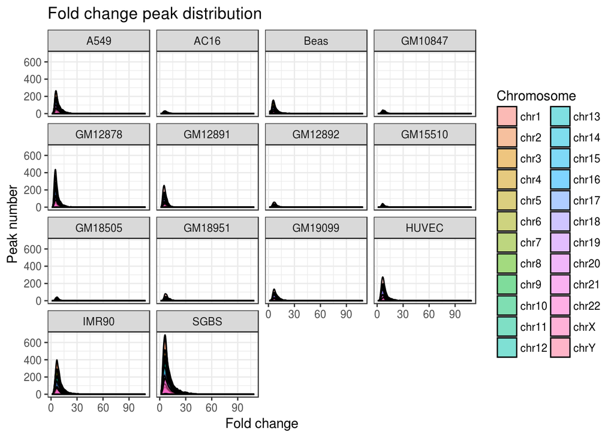

Сделаем диаграммку с распределением длин пиков

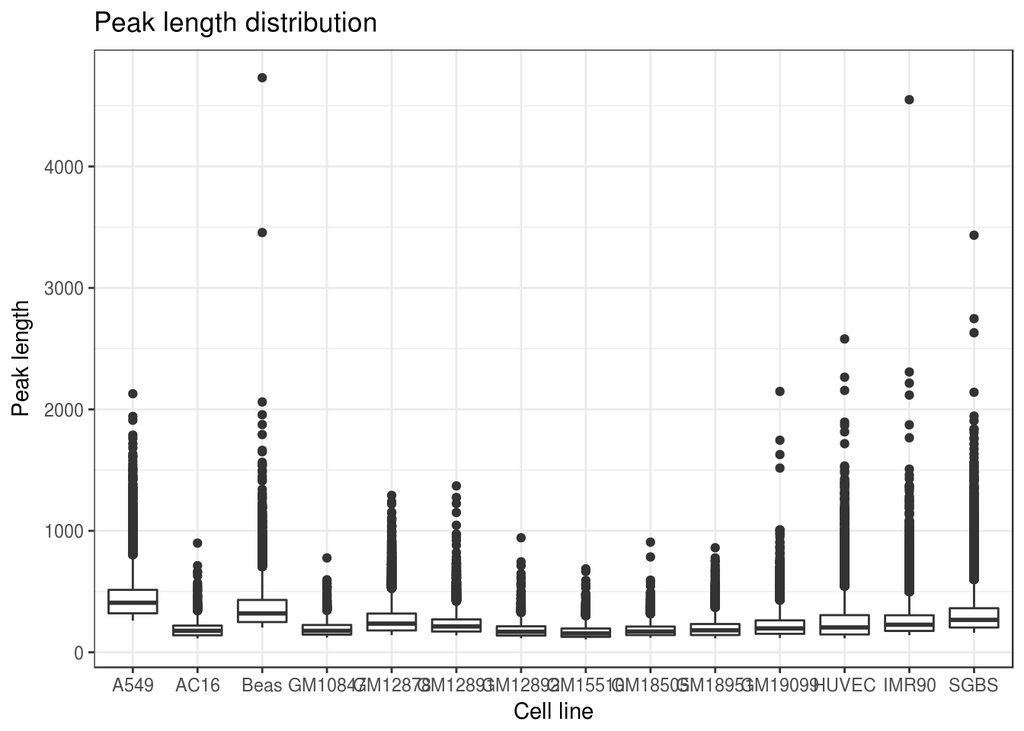

Ну что, картинка длин пиков говорит нам, что все на самом деле в порядке, пики длиной нуклеотидов в 250, просто есть большой разброс по их количеству. И встречаются пики очень длинные для некоторых линий

Ну что же, прикольно. Теперь бинаризуем пики окошком в 50 нуклетоидов

```r
all_peaks <- bin.peaks(all_peaks, window_size = 50)
#Выделим для каждого бина отдельную строку, чтобы было удобнее. Для этого возьмем функцию unnest из пакетика tidyr
all_bins <- unnest(all_peaks, Peak_Bins)
all_bins <- as.data.table(all_bins)
```

## Пересечения бинов

Посмотрим, есть ли пересечения бинов

```r
#Немного говнокода, но мы переживем, зато не надо ничего руками делать
all_intersect <- Reduce(intersect, all_bins[, .(list(unique(Peak_Bins))), Cell_line]$V1)
```

Итого,количество общих бинов 310

Теперь отберем только общие бины, остальные нас уже не интересуют

```r
common_bins <- all_bins[all_bins$Peak_Bins %in% all_intersect, ]
```

## Аннтотация общих бинов

Глянем, как они распределены общие бины по хромосомам

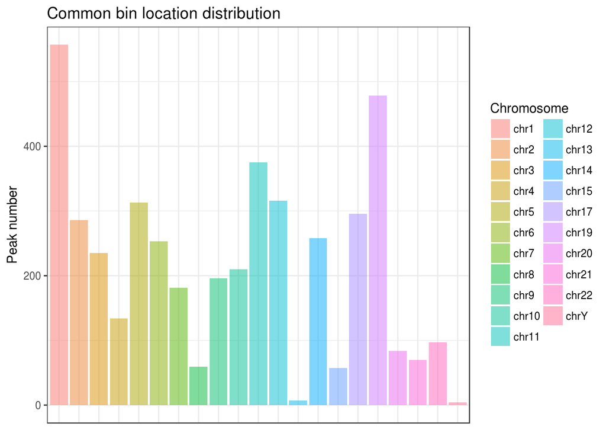

```r
ggplot(common_bins, aes(Chromosome, fill = Chromosome))+
  geom_histogram(aes(fill=Chromosome), alpha = 0.5, stat = "count") +
  labs(title = "Common bin location distribution",
       x = "Genome location",
       y = "Peak number")+
   theme(axis.title.x=element_blank(),
        axis.text.x=element_blank(),
        axis.ticks.x=element_blank(),
        panel.background = element_rect(fill = "white",
            colour = NA), panel.border = element_rect(fill = NA,
            colour = "grey20"), panel.grid.major = element_line(colour = "grey92"),
            panel.grid.minor = element_line(colour = "grey92",
                size = 0.25), strip.background = element_rect(fill = "grey85",
                colour = "grey20"), legend.key = element_rect(fill = "white",
                colour = NA), complete = TRUE)
```

Интересно, что же там такое?

Подготовим из переменной с бинами полноценный .bed файл

```r
#Теперь переведем бины обратно в пики
common_peaks <- aggregate(common_bins$Peak_Bins,
                          by = list(common_bins$Peak_name, common_bins$Cell_line),
                          FUN = min)

names(common_peaks) <- c("Peak_name", "Cell_line", "Start")

common_peaks$Stop <- aggregate(common_bins$Peak_Bins,
                          by = list(common_bins$Peak_name,common_bins$Cell_line),
                          FUN = function(x) max(x)+50)[,3]

common_peaks$Chromosome <- aggregate(common_bins$Chromosome,
                          by = list(common_bins$Peak_name),
                          FUN = function(x) x[1])[,2]

common_peaks$Fold_change <- aggregate(common_bins$fold_change,
                          by = list(common_bins$Peak_name),
                          FUN = function(x) x[1])[,2]

common_peaks$'p-value' <- aggregate(common_bins$`p-value`,
                          by = list(common_bins$Peak_name),
                          FUN = function(x) x[1])[,2]

common_peaks$'q-value' <- aggregate(common_bins$`q-value`,
                          by = list(common_bins$Peak_name),
                          FUN = function(x) x[1])[,2]


#Переставим в правильном порядке столбцы, чтобы bedtools съел
common_peaks <- common_peaks[,c("Chromosome", "Start", "Stop", "Peak_name",
                             "Fold_change", "p-value", "q-value", "Cell_line")]

# Проверим, нет ли косяков в .bed файле и запишем в файл
stopifnot(sum(common_peaks$Start > common_peaks$Stop) == 0)
fwrite(common_peaks, "peaks.bed", sep = "\t", col.names = FALSE)
```

Удалим ненужную переменную

```r
rm(all_intersect)
```

Сделаем бокс-плот, который покажет, как распределены общие пики по fold_change и по q-value в этих клеточных линиях

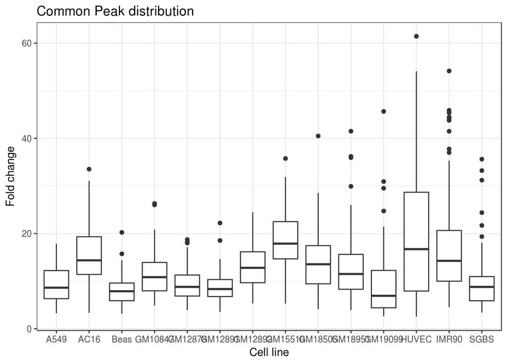

```r
#fold_change для начала
ggplot(common_peaks, aes(Cell_line, Fold_change))+
  geom_boxplot()+
  labs(title = "Common Peak distribution",
       x = "Cell line",
       y = "Fold change")+
  theme_bw()
```

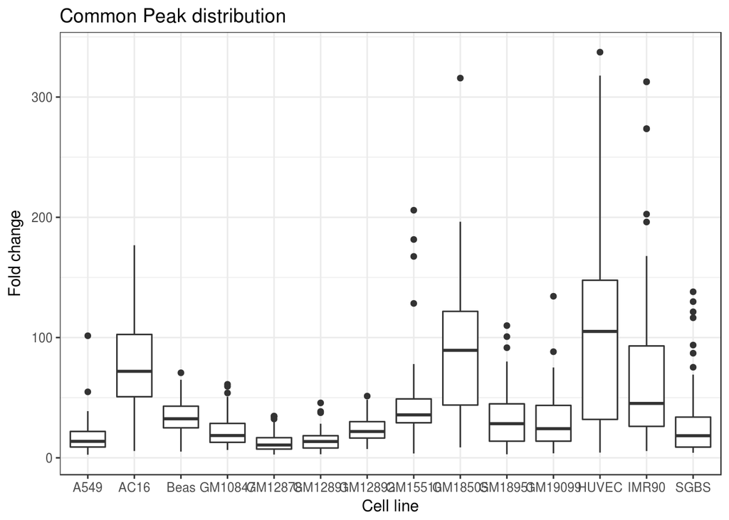

```r
#Теперь q-value
ggplot(common_peaks, aes(Cell_line, common_peaks$`q-value`))+
  geom_boxplot()+
  labs(title = "Common Peak distribution",
       x = "Cell line",
       y = "Fold change")+
  theme_bw()
```

Картинки примерно повторяют друг друга, видим, что самые качественные пики находятся в AC16, GM18505, HUVEC, IMR90

Проаннотируем, как в прошлый раз: Используем ту же аннотацию, которую распарсили

```r
annotation_v24 <- fread("/home/nickolay/R_stuff/NF-kB_sites/Annotation/Gencode_v24.bed")
```

```
##
Read 66.1% of 2570242 rows
Read 2570242 rows and 6 (of 6) columns from 0.123 GB file in 00:00:03
```

```r
#Теперь вытащим только транскрипты
transcripts <- subset(annotation_v24, annotation_v24$Type == "transcript")
transcripts$Type <- NULL
fwrite(transcripts, "transcripts.bed", sep = "\t", col.names = FALSE)
```

Не будем изобретать велосипед, а сделаем скрипт, который с помощью bedtools найдет нам ближайшие гены.

```bash
cd ~/R_stuff/ENCODE_NF-kB_peaks/
#Отсортируем файл с транскриптами и с пиками
sortBed -i transcripts.bed > sorted_transcripts.bed
sortBed -i peaks.bed > sorted_peaks.bed

#А теперь пошли фичи искать
closestBed -D b -k 2 -a sorted_peaks.bed -b sorted_transcripts.bed > closest_transcripts.bed
```

Окей, нашли ближайшие транскрипты, отфильруем их

```r
features <- fread("closest_transcripts.bed")
names(features) <- c("Chromosome", "peak_Start", "peak_Stop", "Peak_name",
                             "Fold_change", "p-value", "q-value", "Cell_line",
                     "Chr", "transcript_Start", "transcript_Stop", "Strand",
                     "Ensemble_ID", "distance")
features$Chr <- NULL
# Убрали пики, которые лежат очень далеко в пустоте, т.е. от них до гена более 3000 нуклеотидов

features <- subset(features, features$distance<3000 & features$distance > - 3000)

#Удалим хвостики у названий транскриптов
features$Ensemble_ID <- gsub("\\.\\d+", "", features$Ensemble_ID)
```

Теперь попробуем проаннотировать гены по GO

```r
library(biomaRt)

# define biomart object
mart <- useMart(biomart = "ensembl", dataset = "hsapiens_gene_ensembl")

# query biomart
BM_out <- getBM(attributes = c("chromosome_name","ensembl_transcript_id",
                               "uniprotswissprot", "hgnc_symbol",
                               "transcript_biotype", "name_1006",
                                "namespace_1003"),
                 filters = "ensembl_transcript_id",
                values = features$Ensemble_ID,
                mart = mart,
                uniqueRows = TRUE)
rm(mart)
```

Теперь, когда у нас есть огромная аннотация, надо ее расчистить

```r
#Удалим неинформативные GO
BM_out <- BM_out[BM_out$name_1006 != "molecular_function" &
                  BM_out$name_1006 != "cellular_component" &
                   BM_out$name_1006 != "biological_process" ,]

GO_data <- BM_out %>% group_by(namespace_1003, ensembl_transcript_id)
names(GO_data) <- c("Chromosome", "Ensemble_ID", "Uniprot_ID", "Gene_symbol", "Biotype",  "GO_name", "Namespace")
rm(BM_out)
```

Славно, теперь давай докинем высоту пиков в разных линиях

```r
#Сделаем маленький датасет со всем необходимым
features <- features[ , c("Ensemble_ID", "distance", "peak_Start", "peak_Stop","Cell_line", "Fold_change", "p-value", "q-value")]

final_peaks <- merge(GO_data, features)
fwrite(final_peaks, "final_peaks.txt")
rm(features, GO_data)
```

Так, теперь посмотрим на те гены, около которых лежат общие бины

Не будем учитывать ничего, просто посмотрим, какие есть

```r
final_genes <- unique(final_peaks[final_peaks$Biotype == "protein_coding","Gene_symbol"])
write.csv(final_genes, file = "final_genes.csv", quote = F, row.names = F, col.names = F)
```

Всего генов вышло - 290

Вот и славно,все вроде заджойнилось Теперь давай-ка глянем на функции, которые у нас вылезли по GO:

```r
mf_table <- table(subset(final_peaks$GO_name, final_peaks$Namespace == "molecular_function"))

cc_table <- table(subset(final_peaks$GO_name, final_peaks$Namespace == "cellular_component"))

bp_table <- table(subset(final_peaks$GO_name, final_peaks$Namespace == "biological_process"))

head(sort(mf_table, decreasing = T))
```

```
##
##      protein binding    metal ion binding          DNA binding
##                  557                  204                  177
##     zinc ion binding          ATP binding transferase activity
##                  133                  119                  105
```

```r
head(sort(bp_table, decreasing = T))
```

```
##
## regulation of transcription, DNA-templated
##                                        234
##                                  transport
##                                        210
##               transcription, DNA-templated
##                                        154
##         multicellular organism development
##                                        130
##                        signal transduction
##                                        116
##   negative regulation of apoptotic process
##                                         98
```

```r
head(sort(cc_table, decreasing = T))
```

```
##
##                       membrane integral component of membrane
##                            569                            390
##                        nucleus                      cytoplasm
##                            386                            365
##                        cytosol                plasma membrane
##                            354                            288
```

```r
rm(mf_table, cc_table, bp_table)
```

Panther reactome pathways нам говорит, что с p-value 4.78E-02 обогащен apoptosis pathway Это немного странно, надо разбираться.

Посмотрим, на то, как распределены гены относительно TSS

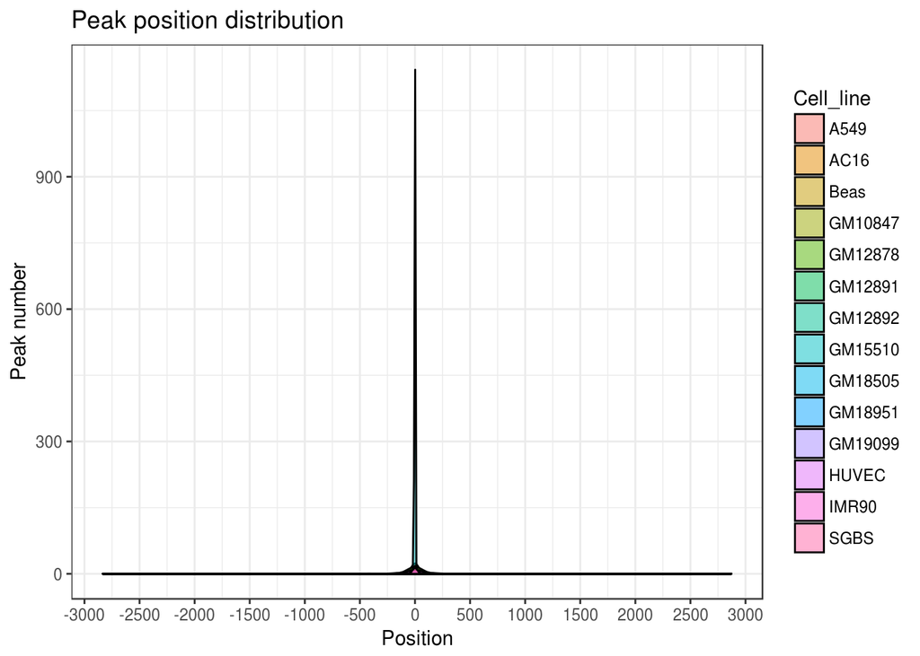

```r
ggplot(final_peaks, aes(distance, ..count..))+
  geom_density(aes(fill=Cell_line), alpha = 0.5) +
  labs(title = "Peak position distribution",
       x = "Position",
       y = "Peak number")+
    scale_x_continuous(breaks = seq(-3000, 3000, 500))+
  theme_bw()
```

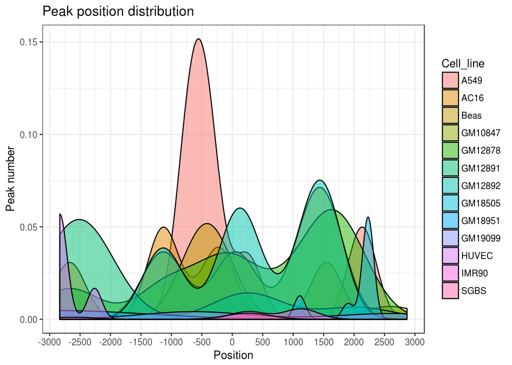

```r
ggplot(final_peaks[final_peaks$distance!=0,], aes(distance, ..count..))+
  geom_density(aes(fill=Cell_line), alpha = 0.5) +
  labs(title = "Peak position distribution",
       x = "Position",
       y = "Peak number")+
    scale_x_continuous(breaks = seq(-3000, 3000, 500))+
  theme_bw()
```

Интересный график, понимать буквально я, его, конечно не буду

## Кластеризация

Теперь попробуем раскластерить линии по всем бинам

```r
#Для того, чтобы все получилось, нужно сделать правильную матричку
ncells <- length(unique(all_bins$Cell_line))
nbins <- max(all_bins[,.N, by=Cell_line]$N)
bins <- matrix(data=NA, nrow = ncells,
               ncol = nbins,
               dimnames =list(unique(all_bins$Cell_line)))
rm(nbins)

#Теперь мы ее заполним
for (i in unique(all_bins$Cell_line)){
  length = length(all_bins[Cell_line == i, Peak_Bins])
  bins[i, 1:length] <- all_bins[Cell_line == i, Peak_Bins]
}


#Теперь можно приступать к кластеризации
distance <- dist(bins, method = "euclidean") # distance matrix
fit <- hclust(distance, method="ward")
```

```
## The "ward" method has been renamed to "ward.D"; note new "ward.D2"
```

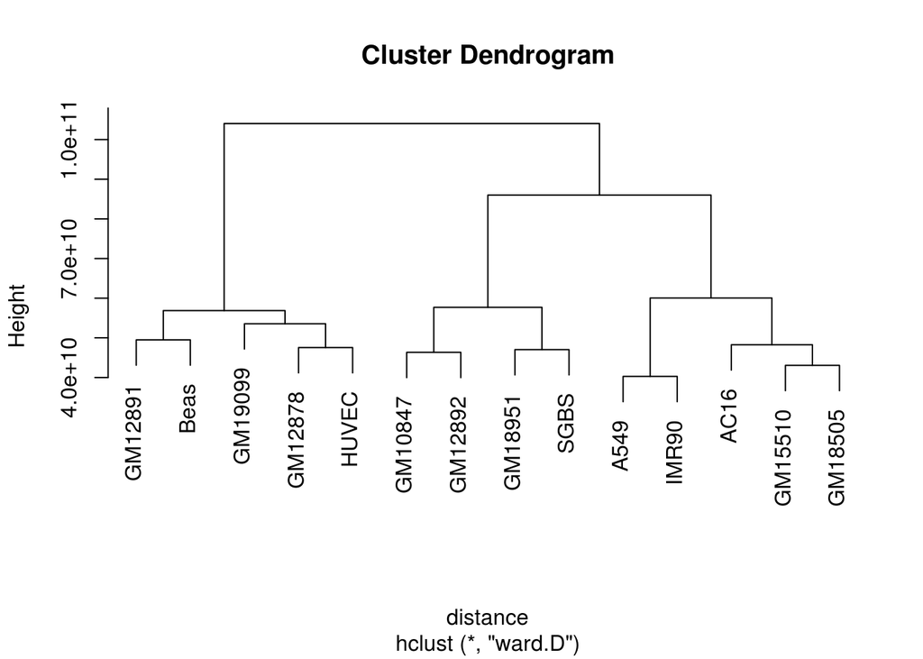

```r
plot(fit) # display dendogram
```

```r
rm(fit, distance, bins)
gc()
```

```
##            used  (Mb) gc trigger  (Mb) max used  (Mb)
## Ncells  3546121 189.4    5684620 303.6  4703850 251.3
## Vcells 37219076 284.0   62413709 476.2 51884552 395.9
```

Ну-ка, интересненько! Что мы имеем - 3 кластера, достаточно четко очерченных Давай разбираться, что к чему

Итак, первый кластер

[output not shown]

Второй кластер

| Клеточная линия | Количество бинов | Происхождение |
| --- | --- | --- |
| GM12891 | 68520 | B-lymphoblastoid, male, caucasian, EBV-transformed |
| GM19099 | 44024 | B-lymphoblastoid, female, Yoruba, EBV-transformed |
| GM12878 | 133861 | B-lymphoblastoid, female, caucasian, EBV-transformed |
| HUVEC | 100299 | endothelium, newborn, primary |

Третий кластер

| Клеточная линия | Количество бинов | Происхождение |
| --- | --- | --- |
| A549 | 171480 | lung adenocarcinoma, male, caucasian |
| IMR90 | 178436 | lung fibroblast, female, caucasian |
| GM15510 | 8580 | B-lymphoblastoid, ?, ?, EBV-transformed |
| GM18505 | 9399 | B-lymphoblastoid, female, Yoruba, EBV-transformed |

Не очень понятно, что происходит. Но можно с уверенностью сказать, что не число бинов играет решающую роль. Прикольно, что IMR90 и A549 лежат рядом, что как бы намекает, что это связано с происхождением клеток.

## График по сочетаниям

Теперь построим график, который нам скажет, хватит ли, или надобно еще добавить линий

```r
#Скрипт может отожрать очень много оперативы, поставим ограничение по памяти в 10гб
ulimit::memory_limit(10000)
```

```
##  soft  hard
## 10000   Inf
```

```r
#Сделаем лист с векторами, содержащими бины
#Имя каждого элемента - имя линии
bin_vecs <- list()
for (i in unique(all_bins$Cell_line)){
  bin_vecs[[i]] <- all_bins[Cell_line == i, Peak_Bins]
}

#Сделали функцию, которая перебирает все сочетания клеточных линий, заменяет имена линий бинами, и сразу их пересекает
#На вход она берет количество линий и выдает вектор с количеством общих бинов
common_bin_number <- function(x){
  temp <- combn(unique(all_bins$Cell_line), x,
                FUN = function(x) bin_vecs[x],
                simplify = F)
  temp <- sapply(temp, function(x) length(Reduce(intersect, x)))
  return(temp)
}
common_bin_number <- cmpfun(common_bin_number) # Ускорим эту функцию с помощью bytecode compilation
```

```
## Note: no visible global function definition for 'length'
```

```r
#Сделаем датафрейм с именами линий в сочетании в каждой ячейке
#Имя каждого столбца - количество линий в сочетании

comb_df <- matrix(data=NA,
                  nrow = choose(ncells, ncells %/% 2),
                  ncol = ncells,
                  dimnames = list(NULL, seq(from = 1, to = ncells)))
comb_df <- as.data.table(comb_df)

#Заполним датафрейм сочетаниями
#Лучше заменить for на foreach и распараллелить

for (i in 1:ncells){
  comb_df[[i]][1:choose(ncells, i)] <- common_bin_number(as.numeric(i))
}
rm(i)
#Теперь переформуем в 2-столбчатый датасет
comb_df <- as.data.table(t(comb_df))
comb_df$Line_number <- c(1:ncells)

comb_df <- melt(comb_df, id="Line_number")
comb_df$Bin_numbers <- comb_df$value
comb_df$variable <- NULL
comb_df$value <- NULL
comb_df <- comb_df[!is.na(comb_df$Bin_numbers)]

#Запишем в файл
fwrite(comb_df, file = "combinations.tsv", sep = "\t")
rm(bin_vecs)
```

Теперь, после стольких мучений - давай график строить

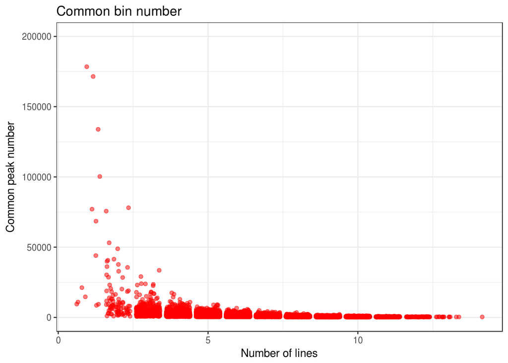

```r
comb_df[, mean(Bin_numbers), by = Line_number]
```

```
##     Line_number         V1
##  1:           1 92314.9286
##  2:           2 13180.3846
##  3:           3  4714.2088
##  4:           4  2500.4446
##  5:           5  1616.7358
##  6:           6  1165.8452
##  7:           7   898.4583
##  8:           8   723.7842
##  9:           9   601.6623
## 10:          10   511.8452
## 11:          11   443.2225
## 12:          12   389.2527
## 13:          13   345.7857
## 14:          14   310.0000
```

Всего вышло 310 общих бинов

## Роль общих бинов в геноме.

ENCODE consortium сделал карту всех регуляторных элементов генома, исходя из своих данных. Сейчас мы глянем, куда что ложится.

Для этого скачал с ENSEMBL через web Biomart  
Данные Human Regulatory Evidence (GRCh38.p10): Regulatory features Regulatory evidence TF binding motifs Other regulatory motifs miRNA target regions

```r
#Импортируем их как таблицу
reg_features <- fread("ENSEMBL_data/reg_features.txt")
miRNA_targets <- fread("ENSEMBL_data/miRNA_targets.txt")
other_regions <- fread("ENSEMBL_data/other_regions.txt")
TF_motifs <- fread("ENSEMBL_data/bind_motifs.txt")
reg_evidence <- fread("ENSEMBL_data/reg_evidence.txt") #Может быть битым
```

```
##
Read 0.0% of 12295477 rows
Read 24.4% of 12295477 rows
Read 48.3% of 12295477 rows
Read 72.7% of 12295477 rows
Read 96.8% of 12295477 rows
Read 12295477 rows and 5 (of 5) columns from 0.429 GB file in 00:00:07
```

```r
#Приведем все эти файлы к единому виду
names(reg_features) <- c("Chromosome", "Start", "Stop", "Feature")
reg_features$Score <- "."
reg_features <- reg_features[Chromosome %in% c(1:22, "X", "Y")]


names(TF_motifs) <- c("Binding_matrix","Chromosome", "Start", "Stop", "Score", "Feature")
TF_motifs <- TF_motifs[, c("Chromosome", "Start", "Stop", "Feature", "Binding_matrix", "Score")]
#Сольем 2 колонки Feature и Matrix через |
TF_motifs$Feature <- paste(TF_motifs$Feature, TF_motifs$Binding_matrix, sep = "|")
TF_motifs$Binding_matrix <- NULL
TF_motifs <- TF_motifs[Chromosome %in% c(1:22, "X", "Y")]

miRNA_targets$`Feature type class` <- NULL
names(miRNA_targets) <- c("Chromosome", "Start", "Stop", "Feature")
miRNA_targets$Score <- "."
miRNA_targets <- miRNA_targets[Chromosome %in% c(1:22, "X", "Y")]

names(other_regions) <- c("Chromosome", "Start", "Stop", "Class", "Feature")
other_regions$Class <- strsplit(other_regions$Class, " ")
other_regions$Class <- sapply(other_regions$Class, function(x) x[1])
other_regions[Feature == "Transcription Start Site", Feature := "TSS"]
other_regions$Feature <- paste(other_regions$Class, other_regions$Feature,  sep = " ")
other_regions$Score <- "."
other_regions <- other_regions[Chromosome %in% c(1:22, "X", "Y")]
other_regions$Class <- NULL


reg_evidence$`Feature type class` <- NULL
names(reg_evidence) <- c("Chromosome", "Start", "Stop", "Feature")
reg_evidence <- reg_evidence[Chromosome %in% c(1:22, "X", "Y")]

#Объединим все датасеты, кроме reg_evidence, с ним будем отдельно работать, если вообще будем
reg_features <- rbindlist(list(reg_features, miRNA_targets, TF_motifs, other_regions))
rm(miRNA_targets, TF_motifs, other_regions)

#Допишем имя хромосомы нормально
reg_features$Chromosome <- paste("chr", reg_features$Chromosome, sep = "")

#Проверяем на косячки
sum(reg_features$Start > reg_features$Stop) #Если 0, то все в порядке
```

```
## [1] 0
```

```r
#Записываем в файл
fwrite(reg_features, file = "reg_features.bed", sep = "\t", col.names = FALSE)
#rm(reg_features)
```

Как оказывается, у нас есть бины, которые входят в несколько пиков сразу в одной клеточной линии, но их мало - вот сколько

```r
tmp <- common_bins[,.N, by=.(Peak_Bins, Cell_line)]
tmp <- tmp[,.N, by=N]
names(tmp) <- c("occurence", "number")
tmp
```

```
##    occurence number
## 1:         1   4218
## 2:         2    118
## 3:         3      4
```

```r
rm(tmp)
```

Теперь сделаем датасет для бинов общих и засунем их в .bed-файл

```r
cell_line <- common_bins[,.N, by=Cell_line]
cell_line <- cell_line[N == min(N), Cell_line] #Выбрали линию, в которой минимальное число повторяющихся бинов

bins_for_bed <- common_bins[Cell_line == cell_line[1], .(Chromosome, Peak_Bins), by=Peak_name]

bins_for_bed <- bins_for_bed[ , .(Chromosome, Start = min(Peak_Bins),
                                  Stop = max(Peak_Bins)+50), by=Peak_name]
bins_for_bed <- bins_for_bed[!duplicated(bins_for_bed), ]
bins_for_bed$Peak_name <- NULL
fwrite(bins_for_bed, file = "common_bins.bed", sep = "\t", col.names = FALSE)
rm(cell_line)
```

Ну-ка, посмотрим, что у нас там в этих общих бинах видно

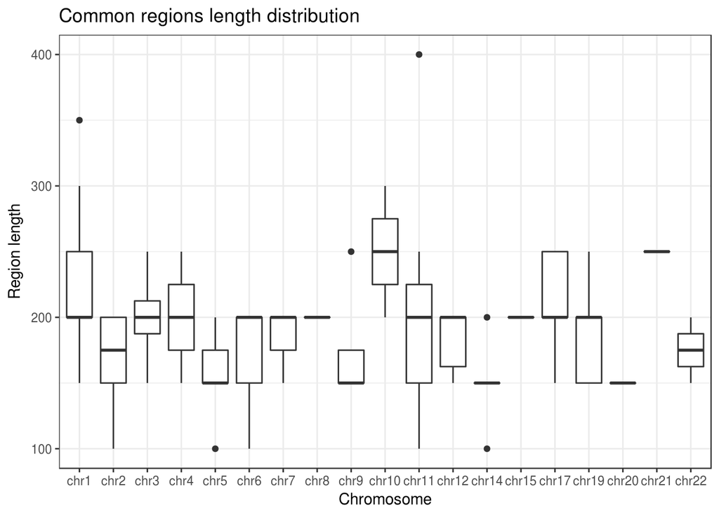

```r
#Распределение по хромосомам
ggplot(bins_for_bed, aes(Chromosome, Stop-Start))+
  geom_boxplot()+
  theme_bw()+
  labs(title = "Common regions length distribution",
       x = "Chromosome",
       y = "Region length")
```

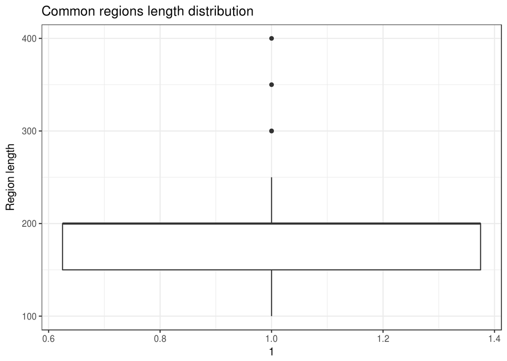

```r
#Распределение всех регионов по длинам. Красота же, видно все!
ggplot(bins_for_bed, aes(x=1 ,Stop-Start))+
  geom_boxplot()+
  theme_bw()+
  labs(title = "Common regions length distribution",
              y = "Region length")
```

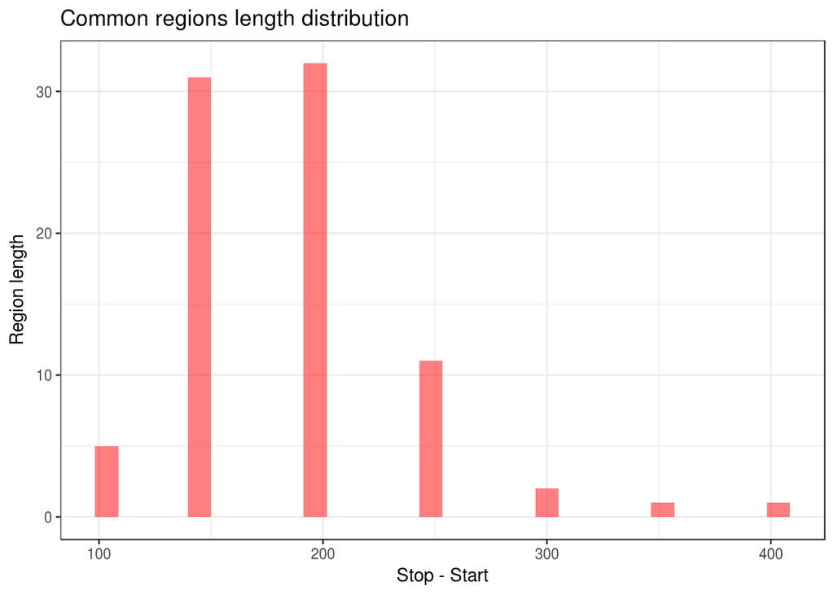

```r
#Распределение всех регионов по длинам. Красота же, видно все!
ggplot(bins_for_bed, aes(Stop-Start, ..count..))+
  geom_histogram(fill ="red", alpha = 0.5)+
  theme_bw()+
  labs(title = "Common regions length distribution",
              y = "Region length")
```

```r
#Посмотрим на чиселки
table(bins_for_bed$Stop - bins_for_bed$Start)
```

```
##
## 100 150 200 250 300 350 400
##   5  31  32  11   2   1   1
```

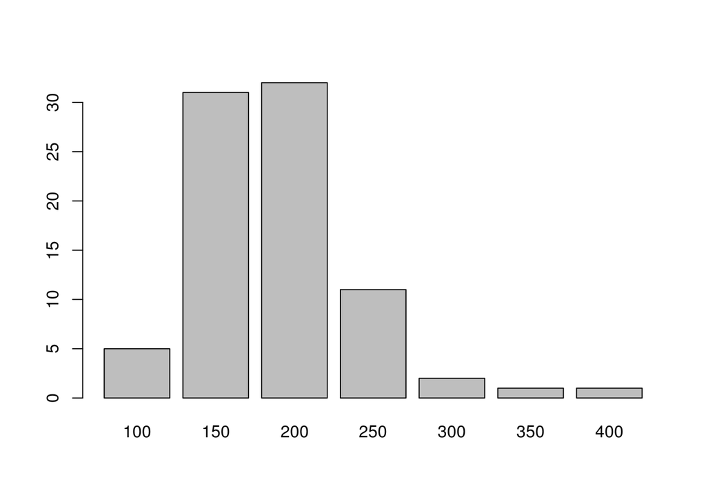

```r
#Видим, что размер этого элемента лежит в области от 150 до 250
barplot(table(bins_for_bed$Stop - bins_for_bed$Start))
```

Теперь на помощь спешит bedtools closest

```bash
cd ~/R_stuff/ENCODE_NF-kB_peaks/
#Отсортируем файл с регуляторными фичами
sort -k 1,1 -k2,2n reg_features.bed > reg_features_sorted.bed
rm reg_features.bed && mv reg_features_sorted.bed reg_features.bed

#Отсортируем файл с бинами
sort -k 1,1 -k2,2n common_bins.bed > common_bins_sorted.bed
rm common_bins.bed && mv common_bins_sorted.bed common_bins.bed

#А теперь пошли фичи искать
closestBed -D b -k 2 -a common_bins.bed -b reg_features.bed > closest_reg_features.bed
```

Возьмем общие бины, и для этих областей посмотрим регуляторные элементы

```r
closest_reg_features <- fread("closest_reg_features.bed", sep = "\t")
names(closest_reg_features) <- c("Chromosome", "peak_Start", "peak_Stop",
                             "Chr", "feature_Start", "feature_Stop",
                     "Feature_name", "Score", "distance")
closest_reg_features$Chr <- NULL

#Уберем все то, что лежит далеко, более чем в 300п.н. - если меньше, то спишем на погрешность

closest_reg_features <- subset(closest_reg_features, closest_reg_features$distance<300 & closest_reg_features$distance > - 300)
names(closest_reg_features)
```

```
## [1] "Chromosome"    "peak_Start"    "peak_Stop"     "feature_Start"
## [5] "feature_Stop"  "Feature_name"  "Score"         "distance"
```

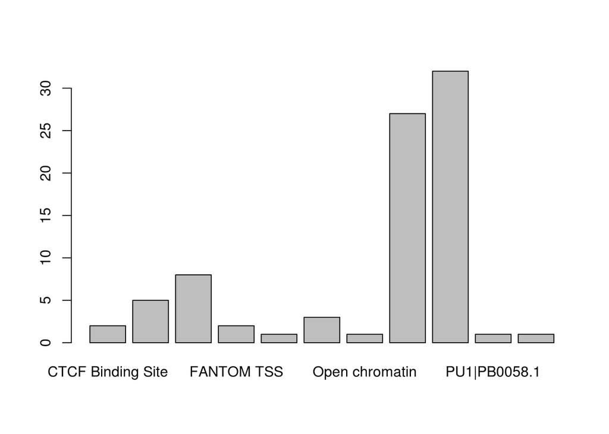

```r
#Сгруппируем по каждому общему участку связывания и посмотрим
summary_reg_features <- closest_reg_features[,.(V5 = list(Feature_name)), by = peak_Start]

#Выкинем дупликации из summary_reg_features

summary_reg_features$V5 <- sapply(summary_reg_features$V5, function(x) x[!duplicated(x)])

#Посмотрим по местоположению:
barplot(table(sapply(summary_reg_features$V5, function(x) x[1])))
```

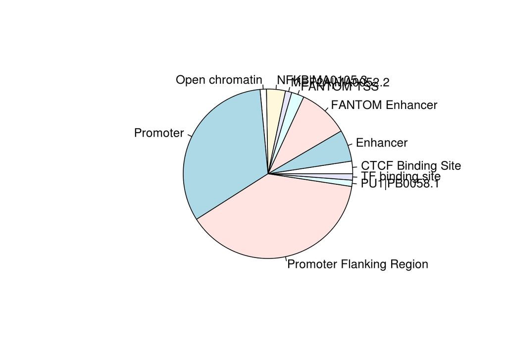

```r
pie(table(sapply(summary_reg_features$V5, function(x) x[1])))
```

```r
#Видно, что эти куски лежат в промоторах и в promoter-flanking regions, а также есть немного в энхансерах
temp <- gsub("\\|.*", "", unlist(summary_reg_features$V5))
top_features <- as.data.table(table(temp))
names(top_features) <- c("Feature", "occurence")
top_features[order(-rank(occurence))]
```

```
##                              Feature occurence
##  1:                             Egr1        59
##  2:                             NFKB        44
##  3:                       FANTOM TSS        32
##  4:         Promoter Flanking Region        32
##  5:                         Promoter        29
##  6:                  FANTOM Enhancer        27
##  7:                             Cjun        21
##  8:                             Jund        14
##  9:                         JUN::FOS        12
## 10:                            FOSL2         9
## 11:                              PU1         9
## 12:                         Enhancer         7
## 13:                             Gabp         5
## 14:                             E2F4         4
```

[output cut: 25 more lines]

```r
#rm(summary_reg_features)
```

Попробуем сфокусироваться на этих ребятах из промоторов и энхансеров

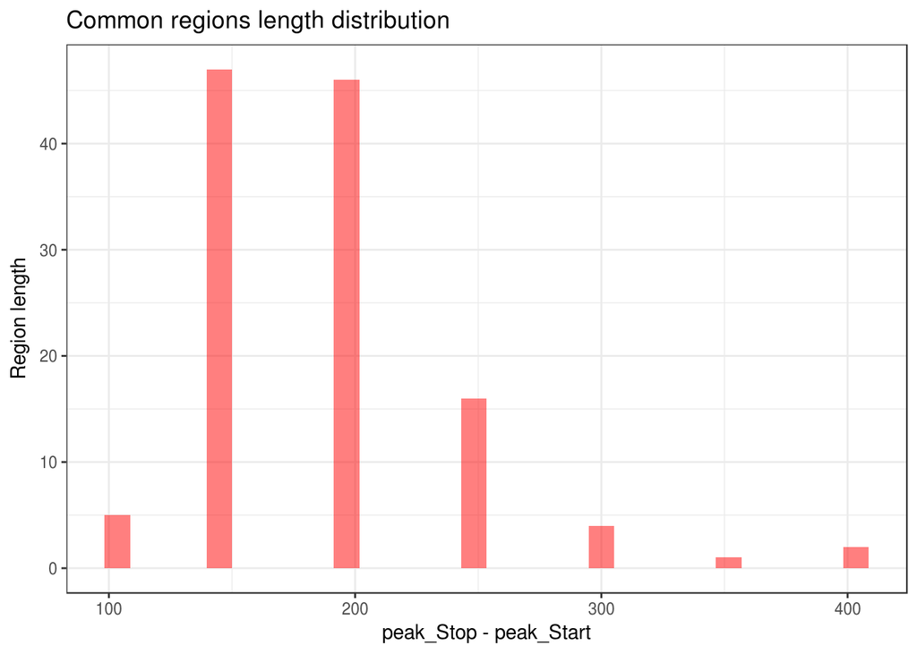

```r
promoenhancers <- closest_reg_features[Feature_name %in% c("Enhancer", "FANTOM Enhancer", "VISTA Enhancer","Promoter", "Promoter Flanking Region")]

#Хм, в длине участков ничего не поменялось
ggplot(promoenhancers, aes(peak_Stop-peak_Start, ..count..))+
  geom_histogram(fill ="red", alpha = 0.5)+
  theme_bw()+
  labs(title = "Common regions length distribution",
              y = "Region length")
```

```r
table(promoenhancers$peak_Stop - promoenhancers$peak_Start)
```

```
##
## 100 150 200 250 300 350 400
##   5  47  46  16   4   1   2
```

```r
rm(promoenhancers)
```

Теперь глянем отдельно на промоторы

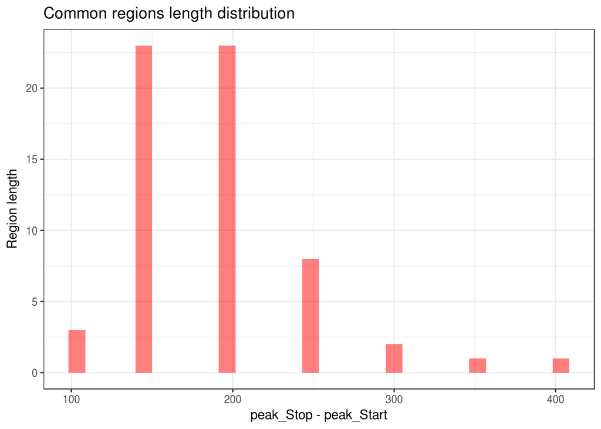

```r
promoters <- closest_reg_features[Feature_name %in% c("Promoter", "Promoter Flanking Region")]

#Хм, в длине участков ничего не поменялось
ggplot(promoters, aes(peak_Stop-peak_Start, ..count..))+
  geom_histogram(fill ="red", alpha = 0.5)+
  theme_bw()+
  labs(title = "Common regions length distribution",
              y = "Region length")
```

```r
table(promoters$peak_Stop - promoters$peak_Start)
```

```
##
## 100 150 200 250 300 350 400
##   3  23  23   8   2   1   1
```

```r
rm(promoters)
```

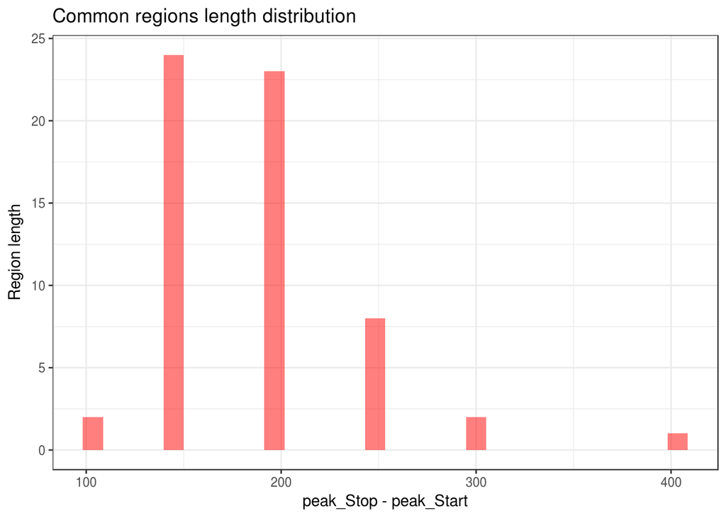

```r
enhancers <- closest_reg_features[Feature_name %in% c("Enhancer", "FANTOM Enhancer", "VISTA Enhancer")]

#Хм, в длине участков ничего не поменялось
ggplot(enhancers, aes(peak_Stop-peak_Start, ..count..))+
  geom_histogram(fill ="red", alpha = 0.5)+
  theme_bw()+
  labs(title = "Common regions length distribution",
              y = "Region length")
```

```r
table(enhancers$peak_Stop - enhancers$peak_Start)
```

```
##
## 100 150 200 250 300 400
##   2  24  23   8   2   1
```

```r
rm(enhancers)
```

Видимо, это все-таки все одно и то же!

## Нормальная аннотация по ближайшим TSS

Проанализируем полученные участки по ближайшим генам Оценим расстояние до ближайшего старт-кодона, его будем определять как первый нуклеотид транскрипта Достанем для начала из аннотации все транскрипты и запишем их в отдельный .bed

```r
start_codons_v24 <- annotation_v24[annotation_v24$Type == "transcript"]
start_codons_v24$Type <- NULL
#Добавим по 10 нуклеотидов к старту, чтобы нормально съел bedtools
start_codons_v24$Stop <- start_codons_v24$Start + 10

#Проверяем на косячки
sum(start_codons_v24$Start > start_codons_v24$Stop) #Если 0, то все в порядке
```

```
## [1] 0
```

```r
#Запишем в файл
fwrite(start_codons_v24, file = "start_codons.bed", sep = "\t", col.names = FALSE)
```

bedtools closest

```bash
cd ~/R_stuff/ENCODE_NF-kB_peaks/
#Отсортируем файл с регуляторными фичами
sort -k 1,1 -k2,2n start_codons.bed > start_codons_sorted.bed
rm start_codons.bed && mv start_codons_sorted.bed start_codons.bed

#А теперь найдем ближайшие TSS
closestBed -D b -k 2 -a common_bins.bed -b start_codons.bed > closest_start_codons.bed
```

Посмотрим, что же вышло

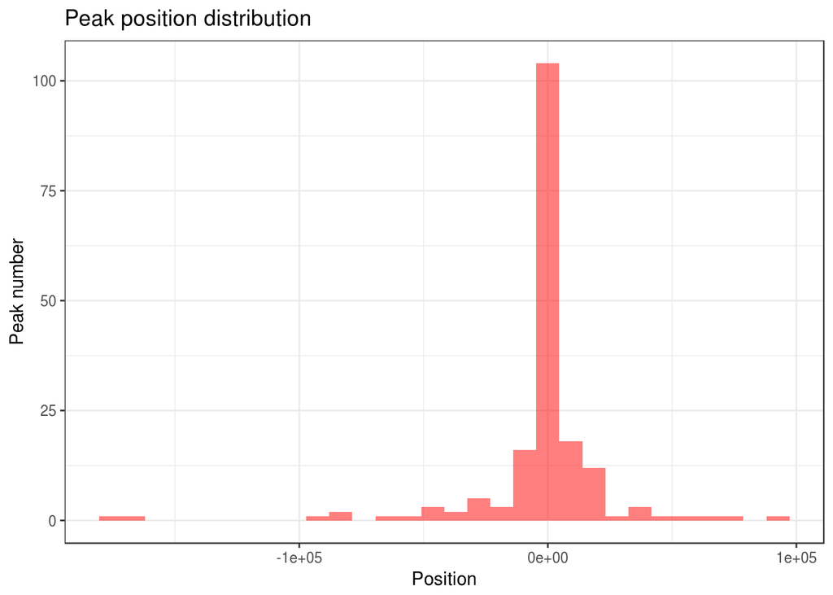

```r
closest_TSS <- fread("closest_start_codons.bed", sep = "\t")
names(closest_TSS) <- c("Chromosome", "peak_Start", "peak_Stop",
                             "Chr", "feature_Start", "feature_Stop",
                     "Strand", "Ensemble_ID", "distance")
closest_TSS$Chr <- NULL

#Удалим хвостики у названий транскриптов
closest_TSS$Ensemble_ID <- gsub("\\:\\d+", "", closest_TSS$Ensemble_ID)

#Уберем дупликаты
closest_TSS <- closest_TSS[!duplicated(closest_TSS)]

#Упорядочим нормально хромосомки, чтобы было красиво
closest_TSS$Chromosome <- factor(closest_TSS$Chromosome,
                                   levels =c("chr1","chr2","chr3","chr4","chr5",
                                             "chr6","chr7","chr8","chr9","chr10",
                                             "chr11", "chr12", "chr13", "chr14", "chr15",
                                             "chr16", "chr17", "chr18", "chr19", "chr20",
                                             "chr21", "chr22", "chrX", "chrY"))

#Построим график, чтобы понимать распределение этих участков относительно TSS

ggplot(closest_TSS, aes(distance))+
  geom_histogram(fill = "red", alpha = 0.5)+
  labs(title = "Peak position distribution",
       x = "Position",
       y = "Peak number")+
  theme_bw()
```

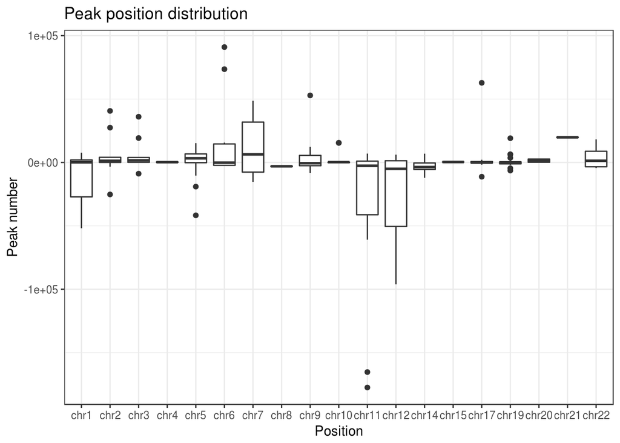

```r
ggplot(closest_TSS, aes(Chromosome, distance))+
  geom_boxplot()+
  labs(title = "Peak position distribution",
       x = "Position",
       y = "Peak number")+
    #scale_x_continuous(breaks = seq(-3000, 3000, 500))+
  theme_bw()
```

Что-то сайты вокруг TSS примерно распределены.

## Консенсусные сайты.

Теперь настает время расковыривать консенсусную последовательность.

Выгрузим наши участки в .fasta файл

```
# define biomart object
mart <- useMart(biomart = "ensembl", dataset = "hsapiens_gene_ensembl")

# query biomart
utr5 = getSequence(chromosome=3, start=185514033, end=185535839,
                   type="entrezgene",
                   seqType="5utr",
                   mart=ensembl)
  getBM(attributes = c("chromosome_name","ensembl_transcript_id",
                               "uniprotswissprot", "hgnc_symbol",
                               "transcript_biotype", "name_1006",
                                "namespace_1003"),
                 filters = "ensembl_transcript_id",
                values = features$Ensemble_ID,
                mart = mart,
                uniqueRows = TRUE)
rm(mart)
```

Для начала попробуем посмотреть, не раскластерятся ли они на 2 группы по последовательностям?

для этого возьмем все наши общие участки, скачаем их последовательности и будем выравнивать

Что теперь надо построить:

1. Какие функции обогащены в самых высоких пиках (Хи-квадрат)
2. Какие пики самые достоверные по q-value во всех линиях
3. Насколько похожи функции в топовых пиках в разных клеточных линиях(ранжированный список)
4. Взять 10 NF-kB зависимых генов и посмотреть, где они лежат в рейтинге
5. Средние высоты пиков для каждой из top 10 функций